# Code to reproduce all figures

```r
library(iTOP)
library(pcalg)
library(readr)
library(bcv)
library(NMF)
library(igraph)
library(Rgraphviz)
library(foreach)
library(doMC)
library(glmnet)
library(TANDEM)
library(latex2exp)
library(beeswarm)
```

If you have trouble installing pcalg, please use the following code (as sometimes installing dependencies from Bioconductor seems to fail for this package):

```r
dependencies = c("Rgraphviz", "graph", "RBGL")
source("https://bioconductor.org/biocLite.R")
for(dependency in dependencies) {
  if(!require(dependency, character.only=T)) {
    biocLite(dependency)
  }
}
install.packages("pcalg")
```

In addition, on some Linux systems, we also needed to install some additional libraries:

- sudo apt-get install libv8-3.14-dev
- sudo apt-get install libgmp3-dev

# Figure 1

Is actually a cartoon that is not based on actual data, but rather meant as a high-level description of the manuscript. Hence, there is no code for figure 1.

# Figure 2

A very simple example of using the RV coefficient to compare datasets.

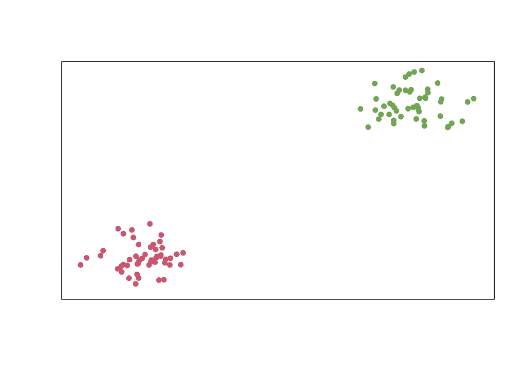

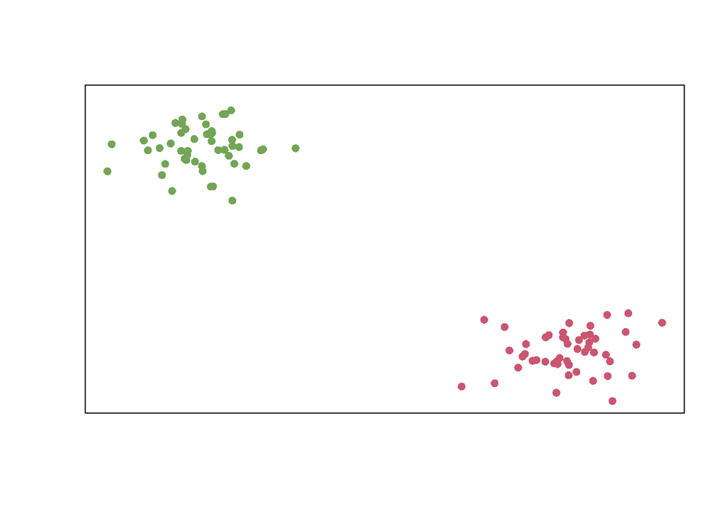

```r
col = rep(c("#ca5670","#72a555"), each=50)

set.seed(1)
n = 100
p = 2
x = matrix(rnorm(n*p),n,p)
x[1:50,] = x[1:50,] - 10
y = matrix(rnorm(n*p),n,p)
y[1:50,1] = y[1:50,1] + 10
y[1:50,2] = y[1:50,2] - 10
z = matrix(rnorm(n*p),n,p)

x = scale(x, scale=F)
y = scale(y, scale=F)
z = scale(z, scale=F)

data = list(x, y, z)
xlim = c(min(x[,1], y[,1], z[,1]), max(x[,1], y[,1], z[,1]))
ylim = c(min(x[,2], y[,2], z[,2]), max(x[,2], y[,2], z[,2]))
q = length(data)
for(i in 1:q) {
  plot(data[[i]], xlab="", ylab="", ylim=ylim, xlim=xlim, col=col, pch=16, xaxt="n", yaxt="n")
}
```

[figure not shown]

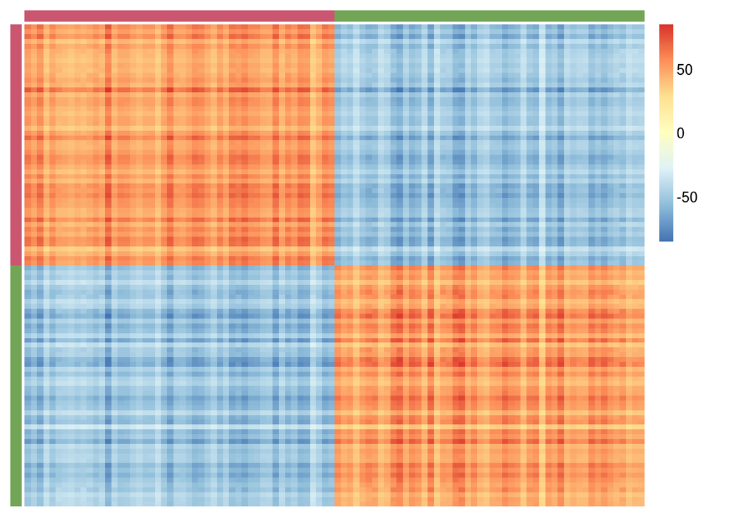

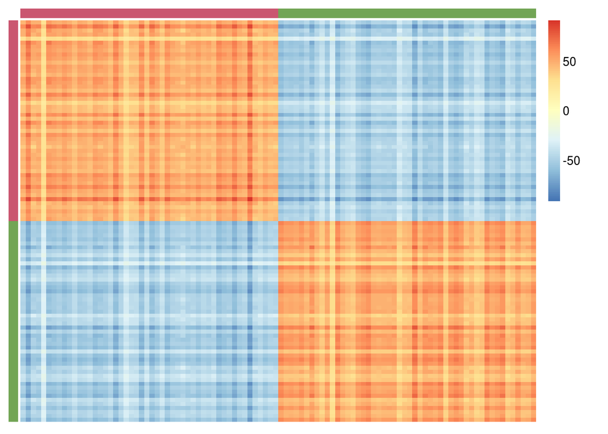

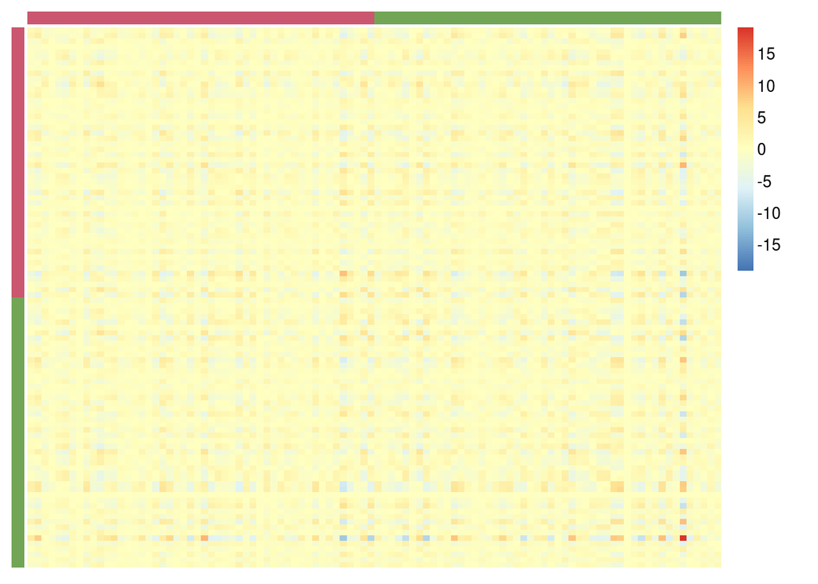

```r
config_matrices = compute.config.matrices(data, mod.rv=F)

ann = data.frame(Var1=factor(col, levels=unique(col)))
annColors = list(Var1=unique(col))
for(i in 1:q) {
  aheatmap(config_matrices[[i]], Rowv=NA, Colv=NA, cexRow=0, cexCol=0, breaks=0, annCol=ann, annRow=ann, annLegend=F, annColors=annColors)
}
```

# Figure 3

A simple example of a partial matrix correlation. The last figure shows that the inferred structure (using the PC algorithm) indeed recovers the structure underlying the data (x -> y -> z).

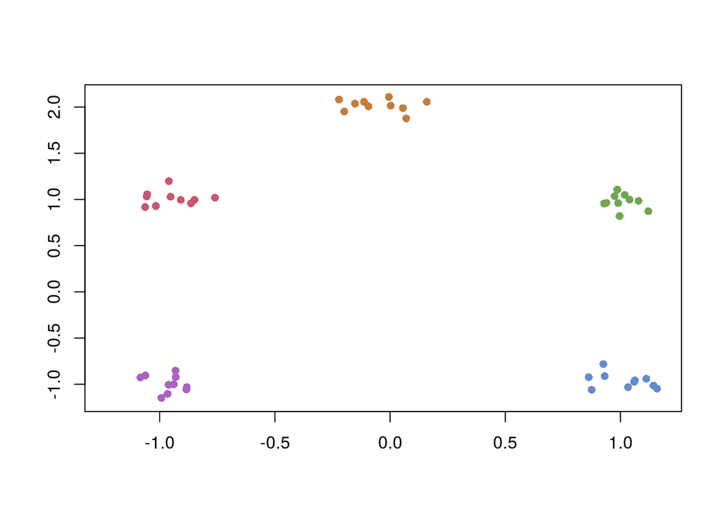

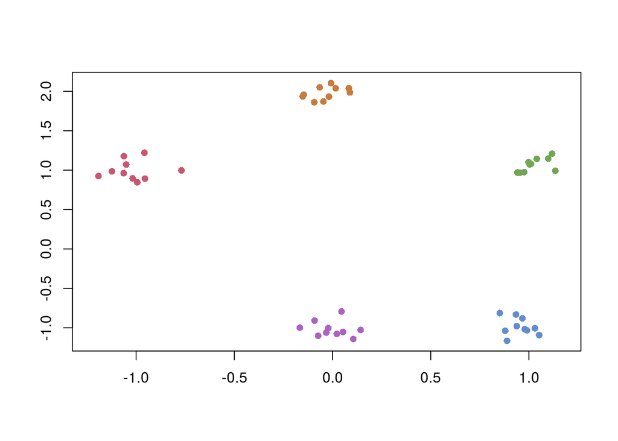

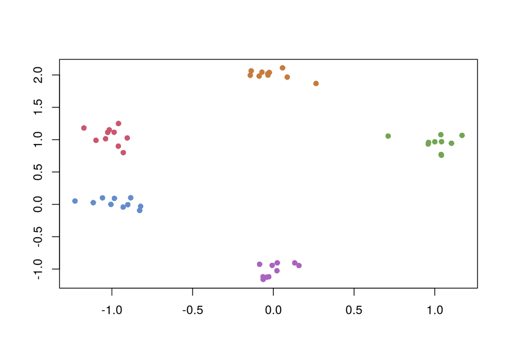

```r
col = rep(c("#ca5670","#72a555","#ab62c0","#c57c3c","#638ccc"), 10)

set.seed(1)
create.data = function(x) {
  n = nrow(x)
  p = ncol(x)
  x2 = NULL
  for(i in 1:10) {
    x2 = rbind(x2, x+0.1*matrix(rnorm(n*p),n,p))
  }
  return(x2)
}

n = 5
p = 2
x = create.data(t(matrix(c(-1, 1, 1, 1, -1, -1, 0, 2, 1, -1), p, n)))
y = create.data(t(matrix(c(-1, 1, 1, 1, 0, -1, 0, 2, 1, -1), p, n)))
z = create.data(t(matrix(c(-1, 1, 1, 1, 0, -1, 0, 2, -1, 0), p, n)))

data = list(x, y, z)
xlim = c(min(x[,1], y[,1], z[,1]), max(x[,1], y[,1], z[,1]))
ylim = c(min(x[,2], y[,2], z[,2]), max(x[,2], y[,2], z[,2]))
q = length(data)
for(i in 1:q) {
  plot(data[[i]], xlab="", ylab="", ylim=ylim, xlim=xlim, col=col, pch=16)
}
```

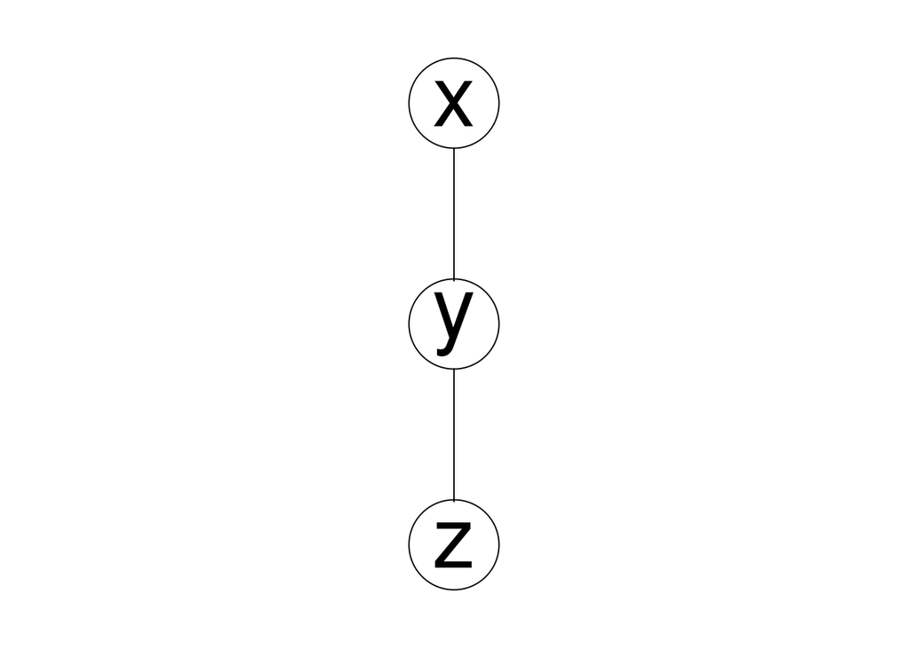

```r
config_matrices = compute.config.matrices(data)
cors = rv.cor.matrix(config_matrices)
nperm = nboots = 1000
cors_boot = run.bootstraps(config_matrices, nboots)
cors_perm = run.permutations(config_matrices, nperm)
suffStat = list(cors=cors, cors_perm=cors_perm)

fit = pc(suffStat=suffStat, indepTest=rv.link.significance, labels=c("x", "y", "z"), alpha=0.01, verbose=F, solve.confl=T, conservative=T)
plot(fit, main="")
```

```r
rv.pcor(cors, 1, 3, 2)
```

```
## [1] 0.005361244
```

```r
rv.conf.interval(cors_boot, 1, 3, 2, .99)
```

```
##       0.5%      99.5%
## -0.2660228  0.2846492
```

```r
rv.pval(cors, cors_perm, 1, 3, 2)
```

```
## [1] 0.354
```

```r
rv.pcor(cors, 1, 2, 3)
```

```
## [1] 0.8777891
```

```r
rv.conf.interval(cors_boot, 1, 2, 3, .99)
```

```
##      0.5%     99.5%
## 0.7705777 0.9422735
```

```r
rv.pval(cors, cors_perm, 1, 2, 3)
```

```
## [1] 0
```

```r
rv.pcor(cors, 2, 3, 1)
```

```
## [1] 0.3695893
```

```r
rv.conf.interval(cors_boot, 2, 3, 1, .99)
```

```
##      0.5%     99.5%
## 0.2054663 0.5217131
```

```r
rv.pval(cors, cors_perm, 2, 3, 1)
```

```
## [1] 0
```